# Analysis of Naomi’s data by Juliette. Influence of the tank on Betta’s behaviour.

Published

December 4, 2023

Remember that we decided to compare Jar/Small/Medium/Large among each other, and Large/Barren between each other, because Jar/Small/Medium and Barren differ by two factors: enrichment and size.

You fill find below the first row of tabs to click on (PCA, Swimming, etc) and for most of these tabs, a second row of tab to click on (Distribution, Plot, etc).

**Data description**

9 behaviours scored: Resting, Swimming, Hovering, Sinking/Floating, Stereotypic swimming, Nest building, Foraging, Interation with surface, Out of view. Out.of.view is a bit special because it is not a behaviour. During a 10 min trial = 600 sec, the fish’s behaviour was assigned to one of the 9 behaviours, meaning that the behaviours are mutually exclusive (a fish can’t be scored as nest building and interacting with the surface at the same time).

After staying 3-7 days in a tank, the behaviour of all fish were scored by 4 trials in this tank. All trials occurred the same day at 4 different times (7 am, 10 am, 2 pm, 6 pm).

```r
summary(data)
```

```
      Fish         Tank        Order             Time          Filter
 Elf    : 20   Jar   :48   Min.   :1.000   7:00 am :63   No-filter:180
 Fairy  : 20   Small :52   1st Qu.:2.000   10:00 am:63   Filter   : 72
 Ghost  : 20   Medium:52   Median :3.000   2:00 pm :63
 Goblin : 20   Large :52   Mean   :2.968   6:00 pm :63
 Kinara : 20   Barren:48   3rd Qu.:4.000
 Kraken : 20               Max.   :5.000
 (Other):132
    Resting          Swimming        Hovering      Sinking.Floating
 Min.   :  0.00   Min.   :  0.0   Min.   :  0.00   Min.   : 0.000
 1st Qu.: 92.33   1st Qu.:133.9   1st Qu.:  6.01   1st Qu.: 0.000
 Median :190.99   Median :224.8   Median : 23.71   Median : 0.000
 Mean   :226.04   Mean   :224.6   Mean   : 42.93   Mean   : 1.221
 3rd Qu.:354.97   3rd Qu.:309.2   3rd Qu.: 56.21   3rd Qu.: 0.000
 Max.   :600.00   Max.   :486.8   Max.   :344.27   Max.   :43.850

 Stereotypic.swimming Nest.building       Foraging      Interation.with.surface
 Min.   :  0.00       Min.   :  0.00   Min.   :  0.00   Min.   :  0.000
 1st Qu.:  0.00       1st Qu.:  0.00   1st Qu.:  0.00   1st Qu.:  0.000
 Median :  0.00       Median :  0.00   Median :  0.00   Median :  1.545
 Mean   : 42.47       Mean   : 33.72   Mean   :  7.83   Mean   : 15.331
 3rd Qu.: 20.58       3rd Qu.:  0.00   3rd Qu.:  7.80   3rd Qu.: 14.117
 Max.   :549.00       Max.   :512.99   Max.   :125.28   Max.   :251.000

  Out.of.view           pc1                pc2                pc3
 Min.   :  0.000   Min.   :-3.61499   Min.   :-3.89170   Min.   :-4.8152
 1st Qu.:  0.000   1st Qu.:-1.10871   1st Qu.:-0.46563   1st Qu.:-0.4014
 Median :  0.000   Median : 0.09616   Median :-0.04024   Median : 0.3869
 Mean   :  7.740   Mean   : 0.00000   Mean   : 0.00000   Mean   : 0.0000
 3rd Qu.:  6.475   3rd Qu.: 1.01284   3rd Qu.: 0.52908   3rd Qu.: 0.6075
 Max.   :247.710   Max.   : 3.80011   Max.   : 3.59677   Max.   : 2.9613

 Foraging.bin SS.bin    Hovering.bin Interacting.bin Nest.bin  SF.bin
 No :168      No :172   No : 48      No :125         No :201   No :218
 Yes: 84      Yes: 80   Yes:204      Yes:127         Yes: 51   Yes: 34
```

```r
# Number of observations per fish per tank
data %>% group_by(Fish, Tank) %>%
  summarise(n=n(), .groups = 'drop') %>%
  spread(Tank,n)
```

```
# A tibble: 13 × 6
   Fish            Jar Small Medium Large Barren
   <fct>         <int> <int>  <int> <int>  <int>
 1 Dragon           NA     4      4     4      4
 2 Elf               4     4      4     4      4
 3 Fairy             4     4      4     4      4
 4 Ghost             4     4      4     4      4
 5 Goblin            4     4      4     4      4
 6 Kinara            4     4      4     4      4
 7 Kraken            4     4      4     4      4
 8 Merlion           4     4      4     4     NA
 9 Naga              4     4      4     4      4
10 Orange Pendek     4     4      4     4      4
11 Pegasus           4     4      4     4      4
12 Phoenix           4     4      4     4      4
13 Wizard            4     4      4     4      4
```

```r
# Number of observations per fish per time
data %>% group_by(Fish, Time) %>%
  summarise(n=n(), .groups = 'drop') %>%
  spread(Time,n)
```

```
# A tibble: 13 × 5
   Fish          `7:00 am` `10:00 am` `2:00 pm` `6:00 pm`
   <fct>             <int>      <int>     <int>     <int>
 1 Dragon                4          4         4         4
 2 Elf                   5          5         5         5
 3 Fairy                 5          5         5         5
 4 Ghost                 5          5         5         5
 5 Goblin                5          5         5         5
 6 Kinara                5          5         5         5
 7 Kraken                5          5         5         5
 8 Merlion               4          4         4         4
 9 Naga                  5          5         5         5
10 Orange Pendek         5          5         5         5
11 Pegasus               5          5         5         5
12 Phoenix               5          5         5         5
13 Wizard                5          5         5         5
```

```r
# Sum of all behaviours per trial
data$total <- rowSums(dplyr::select(data, Resting:Out.of.view))
sort(data$total)
```

```
  [1] 556.750 557.010 559.290 571.820 575.700 583.180 584.820 586.990 588.230
 [10] 588.970 592.550 592.810 592.910 593.320 594.830 595.190 595.330 595.560
 [19] 595.760 595.990 596.190 596.270 596.290 596.500 596.600 596.890 596.910
 [28] 597.288 597.370 597.490 597.610 597.700 597.770 597.830 597.890 598.070
 [37] 598.350 598.470 598.480 598.500 598.640 598.730 598.750 599.060 599.560
 [46] 599.580 599.640 599.720 599.810 600.000 600.000 600.040 600.090 600.290
 [55] 600.400 600.410 600.440 600.610 600.620 600.750 600.780 600.880 600.930
 [64] 601.030 601.050 601.070 601.110 601.300 601.360 601.380 601.470 601.550
 [73] 601.560 601.570 601.630 601.650 601.650 601.670 601.680 601.710 601.750
 [82] 601.770 601.810 601.820 601.820 601.860 601.870 601.960 601.970 602.050
 [91] 602.050 602.060 602.060 602.090 602.090 602.110 602.130 602.160 602.160
[100] 602.170 602.210 602.220 602.370 602.430 602.430 602.450 602.470 602.620
[109] 602.620 602.640 602.660 602.670 602.710 602.740 602.760 602.760 602.790
[118] 602.790 602.870 602.900 602.920 602.960 602.970 602.990 603.000 603.010
[127] 603.100 603.120 603.120 603.170 603.190 603.220 603.220 603.250 603.290
[136] 603.290 603.310 603.360 603.370 603.380 603.390 603.400 603.410 603.450
[145] 603.490 603.520 603.650 603.670 603.690 603.690 603.700 603.720 603.730
[154] 603.800 603.820 603.840 603.880 603.880 603.890 603.910 603.940 604.010
[163] 604.010 604.020 604.040 604.110 604.120 604.130 604.130 604.190 604.200
[172] 604.210 604.230 604.260 604.300 604.300 604.310 604.320 604.350 604.360
[181] 604.360 604.380 604.380 604.400 604.410 604.410 604.430 604.470 604.520
[190] 604.550 604.590 604.610 604.640 604.660 604.660 604.670 604.670 604.680
[199] 604.690 604.710 604.720 604.730 604.750 604.780 604.790 604.810 604.870
[208] 604.890 604.900 604.930 604.930 604.950 604.960 605.000 605.000 605.010
[217] 605.030 605.060 605.280 605.290 605.310 605.330 605.470 605.470 605.570
[226] 605.650 605.780 605.830 605.910 605.980 606.000 606.150 606.360 607.020
[235] 607.170 607.680 607.700 608.260 608.540 608.810 609.200 609.340 609.450
[244] 610.030 610.130 612.490 612.530 614.340 614.850 616.970 622.480 624.680
```

The sum of all behaviours should be 600 sec, it varies between 556.75 and 624.68, but it is alright.

I inspected the data for data entry errors (sum of scored behaviours too low/high, column shifted, typos, inconsistent nb of observations per fish/time/tank…) and Naomi corrected them.

## Plots

The mean value over multiple trials is plotted to only have one value per treatment.

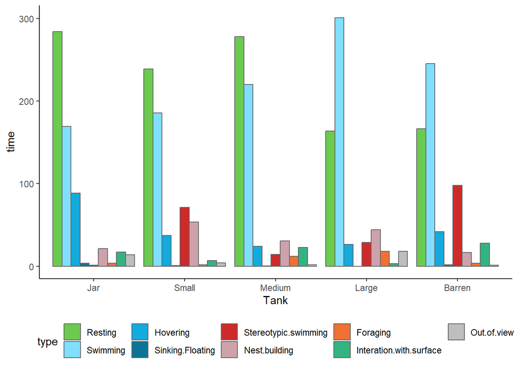

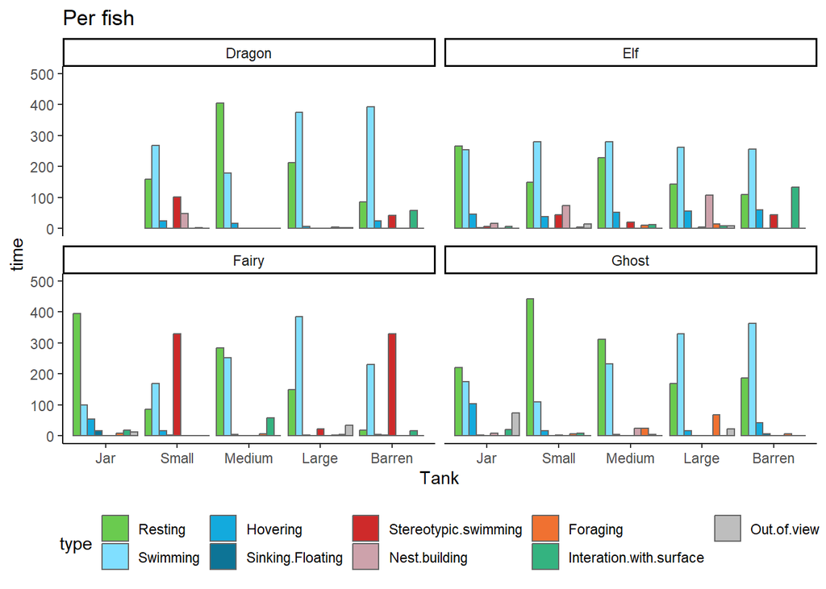

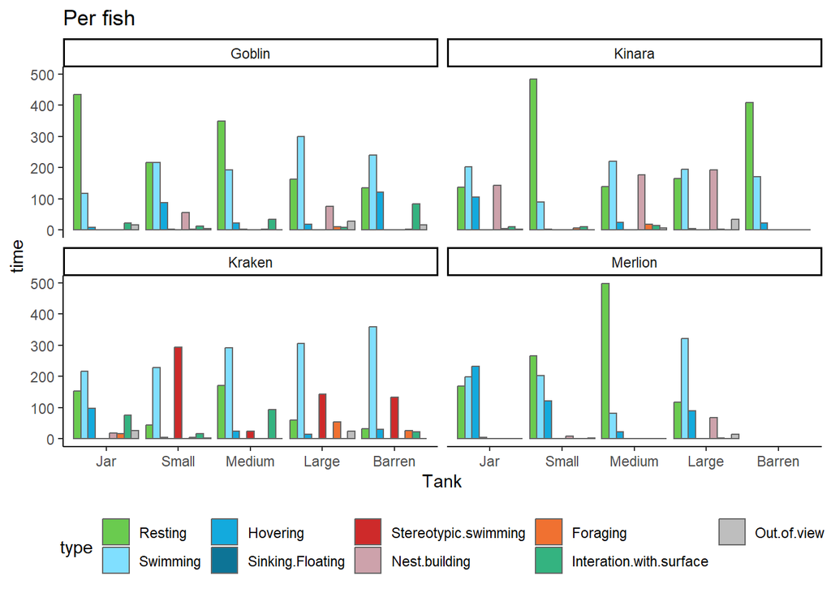

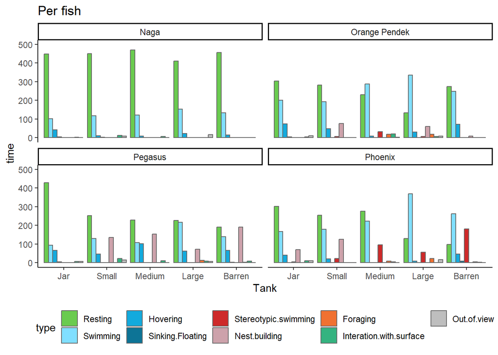

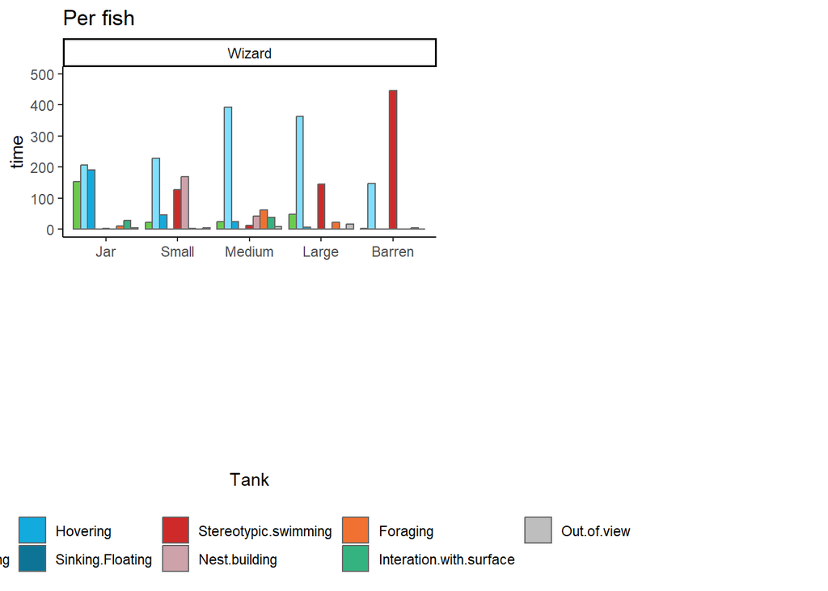

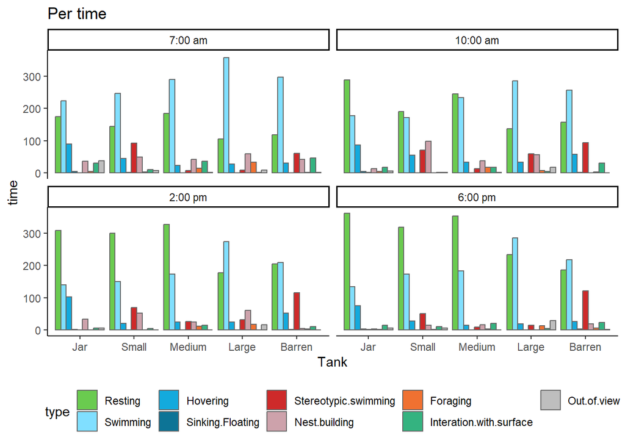

## Filter

```r
# nb of observations per tank with or without filter
table(data$Tank, data$Filter)/4
```

```
         No-filter Filter
  Jar           12      0
  Small         13      0
  Medium         7      6
  Large          7      6
  Barren         6      6
```

```r
# nb of observations per fish with or without filter
table(data$Fish, data$Filter)/4
```

```
                No-filter Filter
  Dragon                1      3
  Elf                   5      0
  Fairy                 2      3
  Ghost                 2      3
  Goblin                5      0
  Kinara                5      0
  Kraken                2      3
  Merlion               4      0
  Naga                  5      0
  Orange Pendek         5      0
  Pegasus               5      0
  Phoenix               2      3
  Wizard                2      3
```

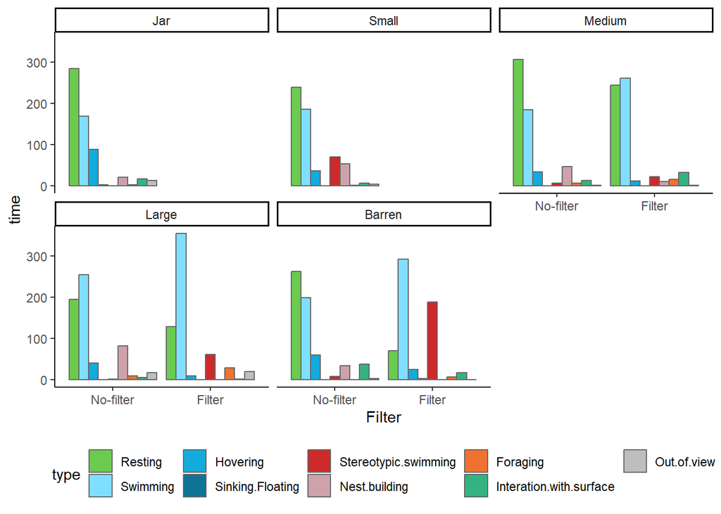

```r
plot1("Filter", "Tank") +  facet_wrap(~Tank)
```

In my opinion, Filter needs to be included in all models as a control variable.

## Order of trials

Visual inspection of any trend in the order of trials, like for instance if there were more swimming during the 2nd trial whatever the tank was.

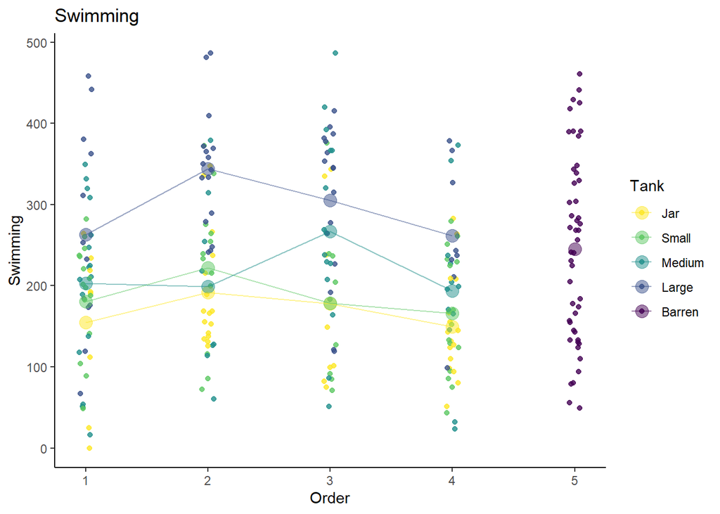

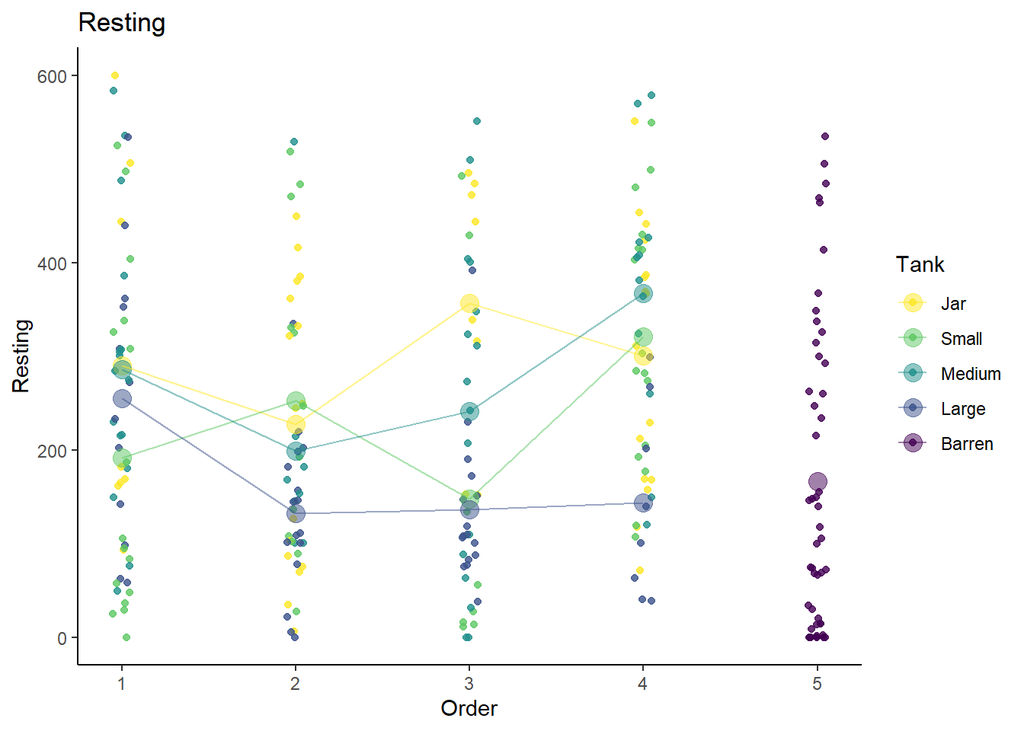

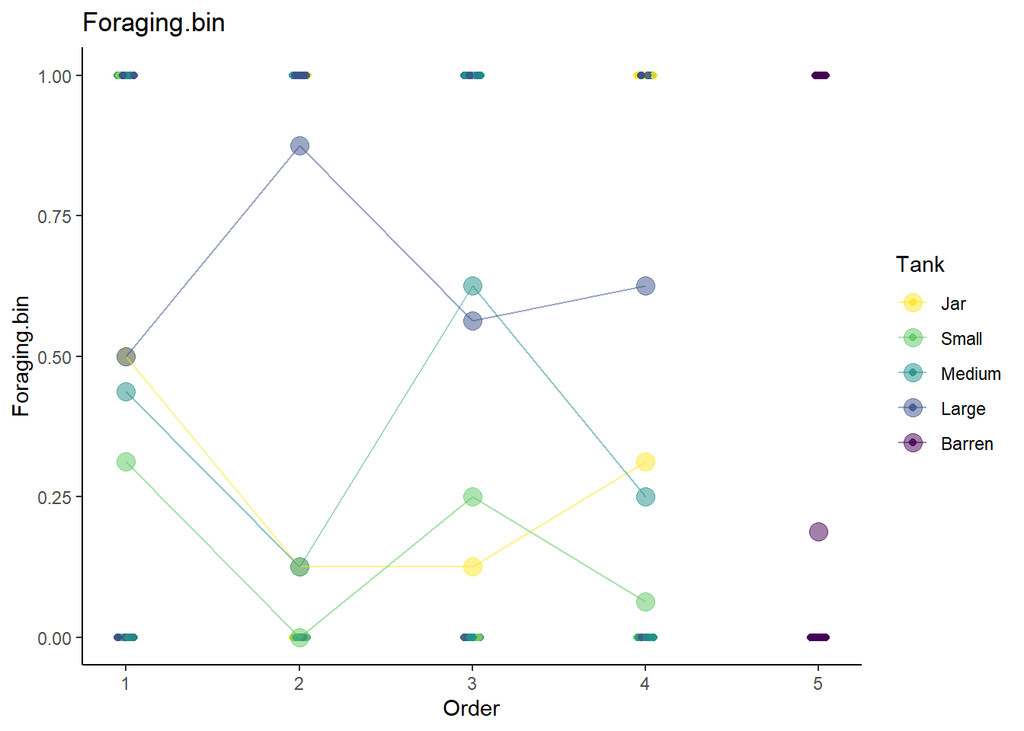

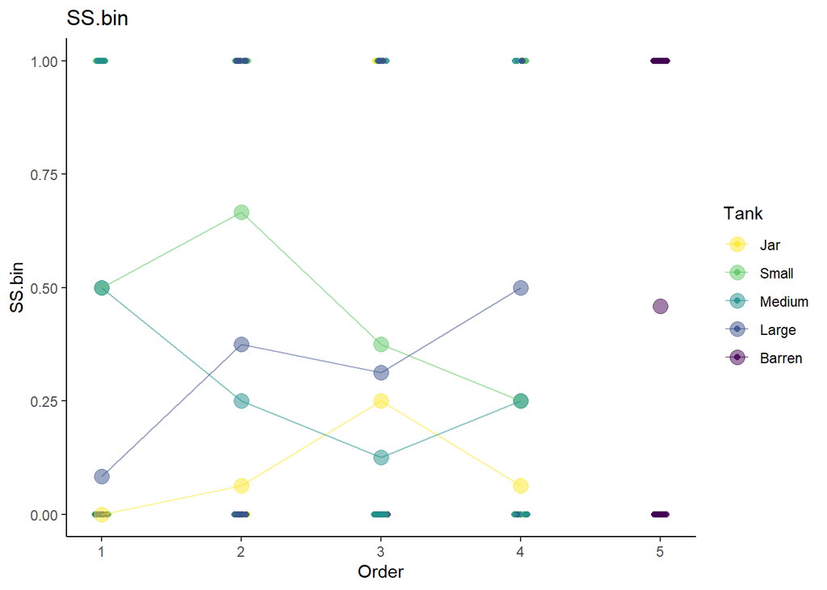

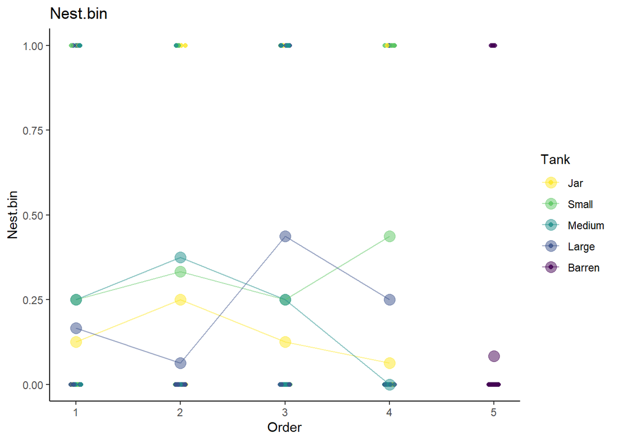

There was no apparent trend in the order of trials (for instance, fish did not perform more swimming at the 2nd trial whatever tank they were in).

**PCA**

We run a PCA in order to:

- Try to reduce the number of variables to analyse (even if we could analyse each behavioural type individually)
- Determine which behavioural types are important to explain the variability between trials
- See correlations between behavioural types

The PCA did not help reduce the number of variables to analyse (see Analysis_PCA.html for more explanation) so I analysed the behavioural types separately + it allows to interpret differences between tanks quantitatively. I still plotted below the first 3 components, which explained 57% of variance in the data, to show the important variables and the correlations between variables.

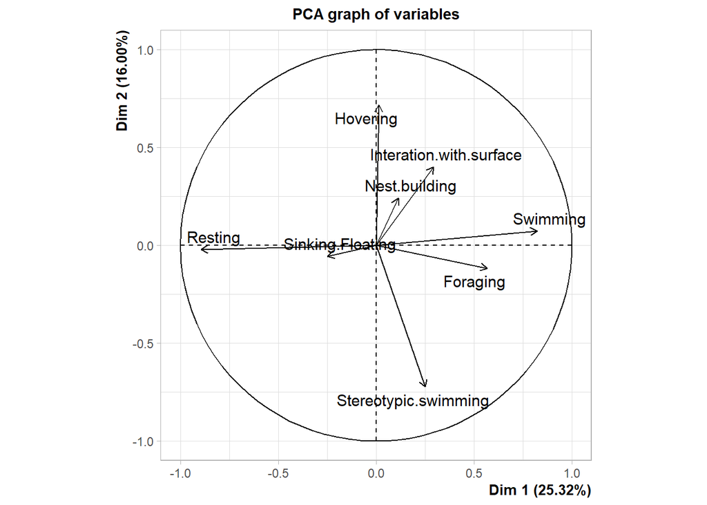

```r
plot(pca, choix = "var", axes = c(1,2))
```

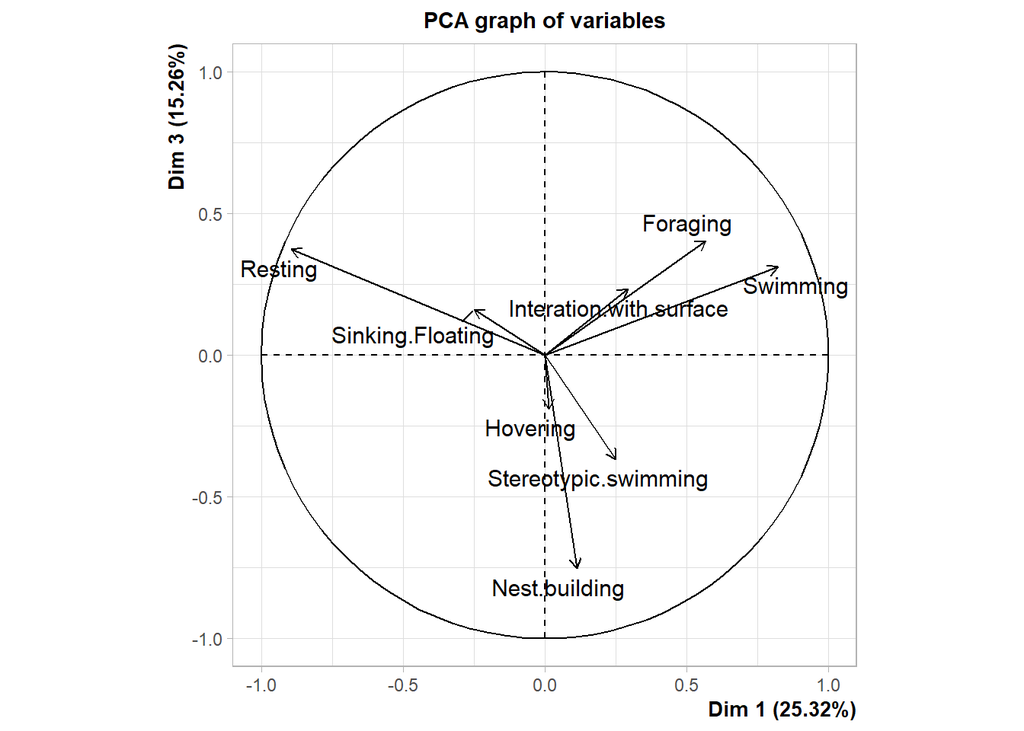

```r
plot(pca, choix = "var", axes = c(1,3))
```

```r
# Contribution to each principal component
round(pca$var$cos2,2)
```

```
                        Dim.1 Dim.2 Dim.3
Resting                  0.80  0.00  0.14
Swimming                 0.68  0.01  0.10
Hovering                 0.00  0.51  0.04
Sinking.Floating         0.06  0.00  0.03
Stereotypic.swimming     0.06  0.52  0.13
Nest.building            0.01  0.06  0.57
Foraging                 0.32  0.01  0.16
Interation.with.surface  0.09  0.16  0.05
```

```r
# Extent to which each behavioural type contributes to the total variance explained by the first 3 components
rowSums(pca$var$contrib)/3
```

```
                Resting                Swimming                Hovering
              17.017016               13.946992               14.360858
       Sinking.Floating    Stereotypic.swimming           Nest.building
               1.811372               18.372673               17.241361
               Foraging Interation.with.surface
              10.134302                7.115428
```

- The 1st PCA component was driven by Resting (cos2 = 0.8), Swimming (0.7) and Foraging (0.3). Swimming and Foraging opposite to Resting. This first component could be interpret as “activity”. If a fish spent a lot of time swimming and foraging during a trial, it was very little resting. This first component explained 25% of the variance in the data (as a reminder, the data is the time spent performing the different types of behaviour). So 1 quarter of the variance is a matter of activity. Keep in mind for the rest of the analyses that these behavioural types are correlated.
- The 2nd PCA component was driven by Hovering (cos2 = 0.5) and Stereotypic.swimming (0.5), and a bit by Interaction with surface (0.16). Hovering and Interacting.with.Surface opposite to Stereotypic.swimming. If the fish spent a lot of time hovering (and interacting with the surface), it was very little stereotypic swimming. This is interesting in my opinion.
- The 3rd PCA component was driven mainly by Nest building (cos2 = 0.6), and a bit by Foraging (0.16), Resting (0.14) and Stereotypic Swimming (0.13). Foraging and Resting opposite to Nest building and Stereotypic Swimming. If a fish spent time foraging and resting in a trial, it was little nest building and stereotypic swimming. This makes sense, it a fish is building a nest,it is an important task and needs to be finished, so it is not scattering its time with other activities. The apparent correlation between nest building and stereotypic swimming could be due to Jar where fish in this tank rarely engaged in nest building or stereotypic swimming.

Sinking/Floating contributed almost nothing to the first three components (2%) + did not correlate strongly with any of the component. Sinking/Floating was not important to explain the variability between trials.

**Swimming**

**Distribution**

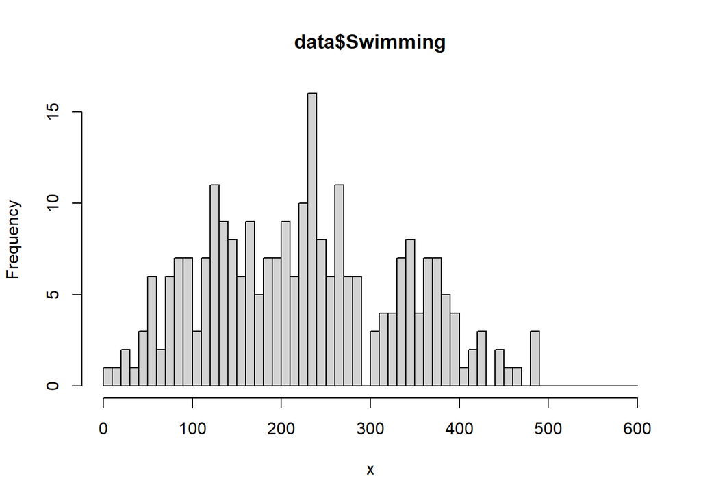

```r
hist1(data$Swimming)
```

**Plot**

The second plot is to see the trend by fish and by tank. Thick red line is the overall mean by tank. Thin black lines are the mean for each fish by tank.

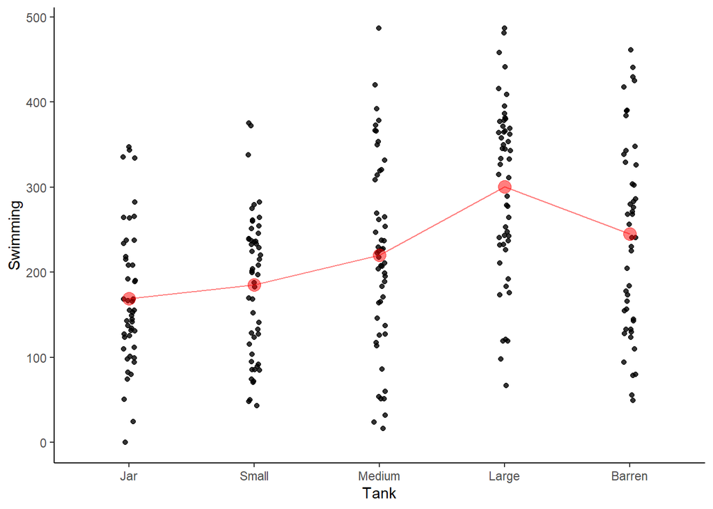

```r
plot_var(data, "Swimming")
```

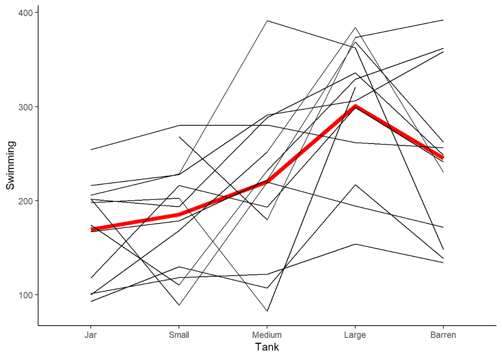

```r
plot_var_fish2(data, "Swimming")
```

**Linear model**

```r
mSwimming <- lmer(Swimming ~ Tank + Time + Filter + (1|Fish), data = data)
lm_results(mSwimming)
```

```
[1] "Anova"
Type II Analysis of Variance Table with Kenward-Roger's method
       Sum Sq Mean Sq NumDF  DenDF F value    Pr(>F)
Tank   240332   60083     4 236.97  10.065 1.535e-07 ***
Time   337219  112406     3 231.05  18.832 5.812e-11 ***
Filter 111221  111221     1 151.81  18.633 2.846e-05 ***
---
Signif. codes:  0 '***' 0.001 '**' 0.01 '*' 0.05 '.' 0.1 ' ' 1
[1] "Fixed effect estimates"
              Estimate Std. Error        df    t value     Pr(>|t|)
(Intercept)  230.42475   17.62338  56.08006 13.0749479 1.139071e-18
TankSmall     13.94555   15.53298 232.50080  0.8978032 3.702193e-01
TankMedium    12.04510   17.35441 242.45042  0.6940658 4.883054e-01
TankLarge     92.58241   17.35441 242.45042  5.3348053 2.193044e-07
TankBarren    34.15435   17.87362 242.45157  1.9108808 5.719932e-02
Time10:00 am -57.75908   13.76555 231.33670 -4.1959149 3.875275e-05
Time2:00 pm  -94.13079   13.76555 231.33670 -6.8381423 7.077352e-11
Time6:00 pm  -84.21841   13.76555 231.33670 -6.1180563 4.007661e-09
FilterFilter  79.23564   17.82223 153.27661  4.4458876 1.671217e-05
[1] "Random effect estimates"
    Effect Variance Repeatability
1     Fish 1469.503           0.2
2 Residual 5968.947            NA
```

```r
calc_contrasts(mSwimming)
```

```
         contrast estimate   SE  df t.ratio p.value lower.CL upper.CL
1    jar_vs_small      -14 15.5 232   -0.90  >0.999      -56       28
2   jar_vs_medium      -12 17.4 242   -0.69  >0.999      -59       35
3    jar_vs_large      -93 17.4 242   -5.31  <0.001     -140      -45
4 small_vs_medium        2 17.4 243    0.11  >0.999      -45       49
5  small_vs_large      -79 17.4 243   -4.53  <0.001     -126      -32
6 medium_vs_large      -81 15.2 231   -5.32  <0.001     -122      -39
7 large_vs_barren       58 15.5 232    3.76  <0.001       16      101
```

Effect of Tank, Time and Filter!

- Tank. Large swam significantly more time than Jar, Small and Medium. Fish in fish in Large swan 93 sec [CI 45, 140] more than Jar (over a 600 sec trial), 79 sec [CI 32, 126] more than Small, and 81 sec [CI 39, 122] more than Medium. In addition, fish in Large swam significantly more time (58 sec [CI 16, 101]) than fish in Barren.
- Time. Fish swim less in the afternoon.
- Filter. Fish swim more with a filter in their tank.

Repeatability is quite low (0.2)

**Diagnosis**

```
[1] "check linearity and constant variance over fitted values"
```

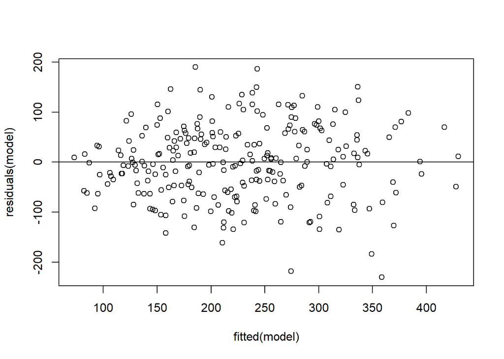

```
[1] "Normality of Swimming"
```

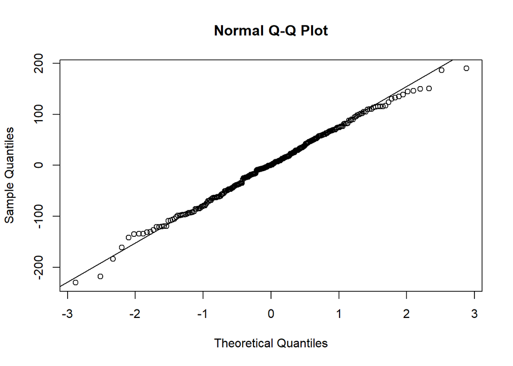

```
[1] "normality random residuals"
```

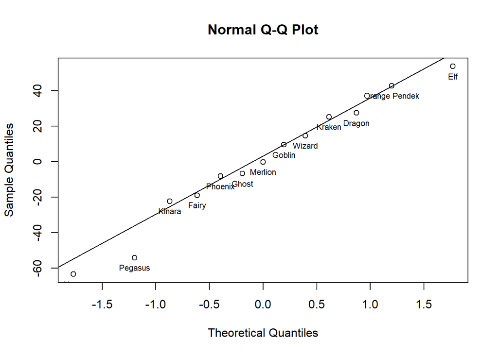

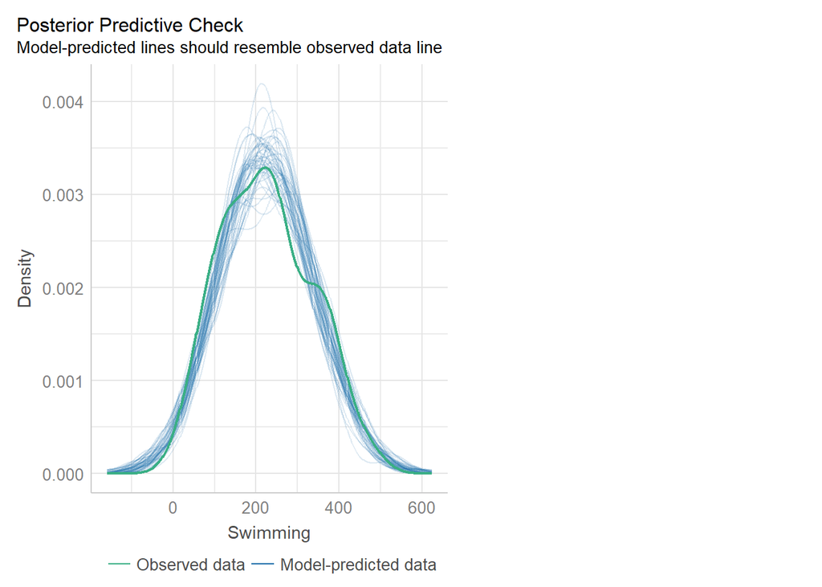

```r
lm_diagnosis(mSwimming)
```

The model seems good.

**Up and down**

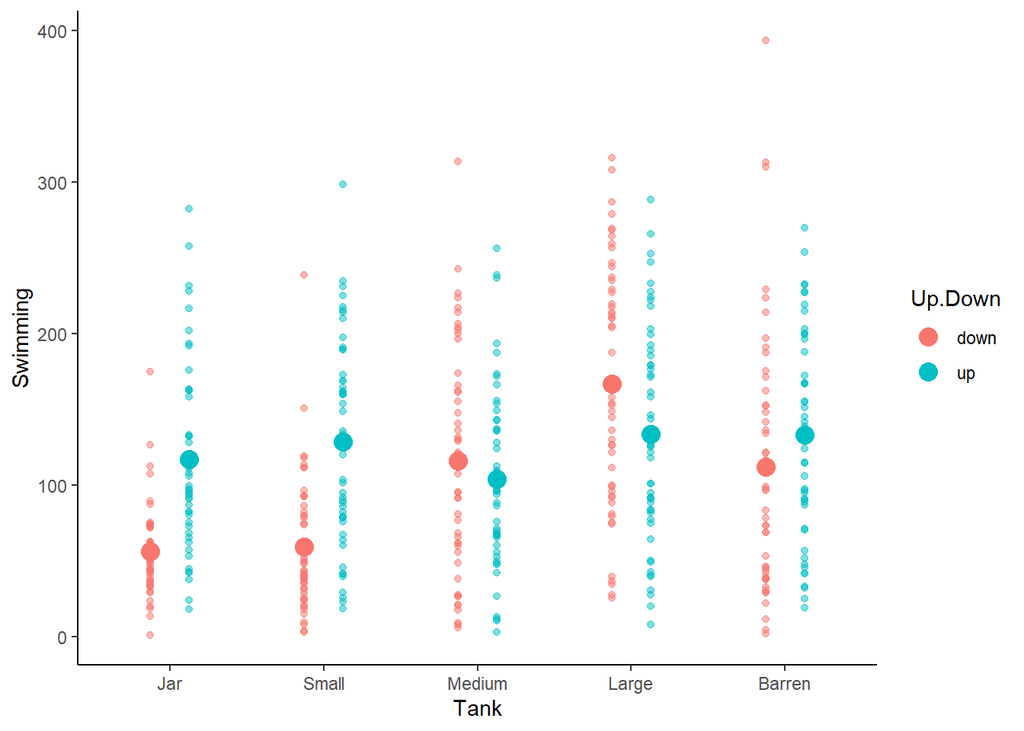

```r
dataUpDown %>% filter(Swimming!=0) %>%
ggplot(.,aes(y = Swimming, x = Tank, color = Up.Down)) +
  geom_jitter(alpha=.5, position = position_dodge(0.5))+
  stat_summary(fun = "mean", geom = "point", size = 4, position = position_dodge(0.5))
```

It seems that the tank has an influence on whether fish prefer swimming on the upper half or lower half of the tank.

**Resting**

**Distribution**

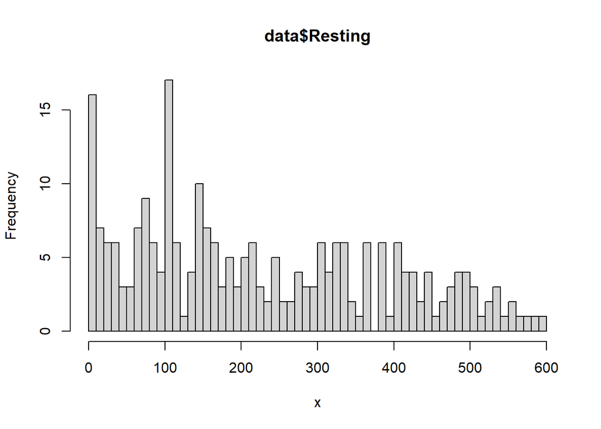

```r
hist1(data$Resting)
```

```r
table(data$Resting==0)
```

```
FALSE  TRUE
  241    11
```

Only 11 trials where the fish did not rest at all.

**Plot**

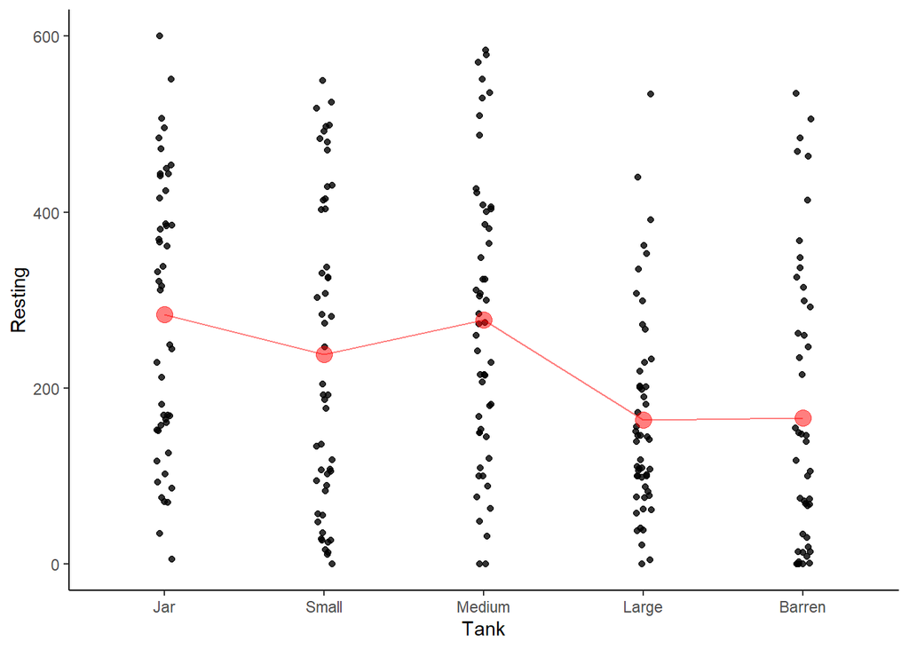

```r
plot_var(data, "Resting")
```

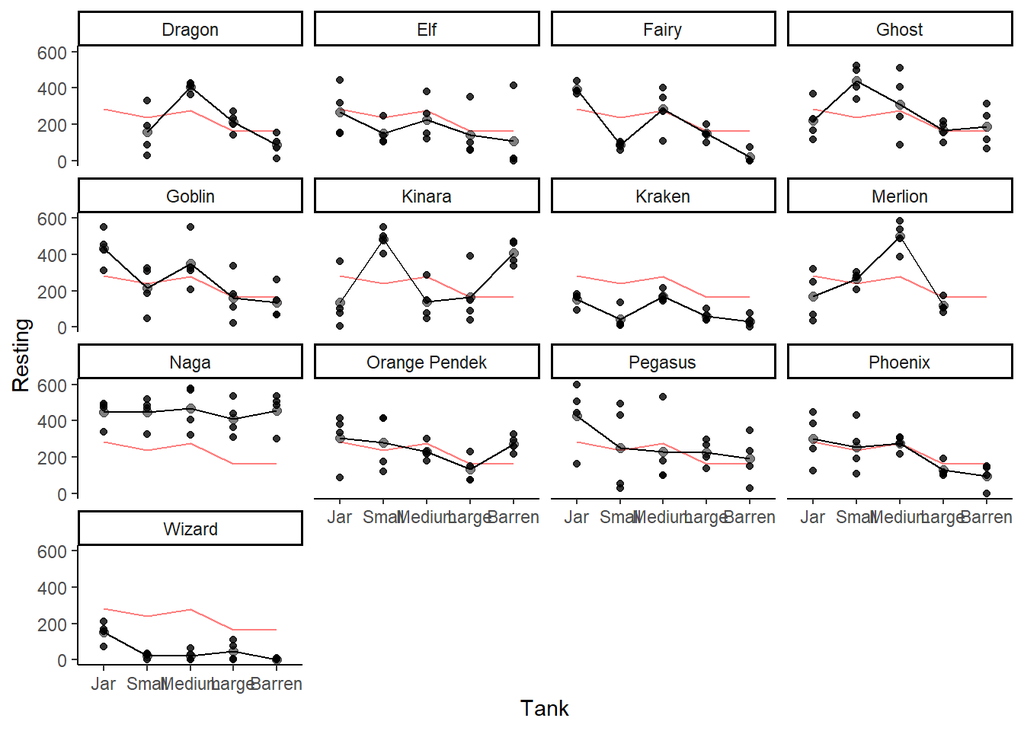

```r
plot_var_fish(data, "Resting")
```

**Linear model**

```r
mResting <- lmer(Resting ~ Tank + Time + Filter + (1|Fish), data = data)
lm_results(mResting)
```

```
[1] "Anova"
Type II Analysis of Variance Table with Kenward-Roger's method
       Sum Sq Mean Sq NumDF  DenDF F value    Pr(>F)
Tank   547562  136891     4 235.30 10.3044 1.049e-07 ***
Time   795993  265331     3 231.01 19.9736 1.514e-11 ***
Filter   9752    9752     1 222.98  0.7341    0.3925
---
Signif. codes:  0 '***' 0.001 '**' 0.01 '*' 0.05 '.' 0.1 ' ' 1
[1] "Fixed effect estimates"
                Estimate Std. Error        df    t value     Pr(>|t|)
(Intercept)   204.583884   32.19805  28.67918  6.3539216 6.371965e-07
TankSmall     -46.439827   23.18944 231.31950 -2.0026283 4.638446e-02
TankMedium      4.141022   26.18252 239.14679  0.1581598 8.744643e-01
TankLarge    -110.004939   26.18252 239.14679 -4.2014650 3.746179e-05
TankBarren   -104.865955   26.96432 239.08519 -3.8890633 1.304557e-04
Time10:00 am   57.730317   20.53576 230.66541  2.8112097 5.360099e-03
Time2:00 pm   117.950317   20.53576 230.66541  5.7436558 2.908300e-08
Time6:00 pm   145.566984   20.53576 230.66541  7.0884646 1.638690e-11
FilterFilter  -24.624757   28.23869 222.41701 -0.8720219 3.841368e-01
[1] "Random effect estimates"
    Effect  Variance Repeatability
1     Fish  7751.688          0.37
2 Residual 13284.095            NA
```

```r
calc_contrasts(mResting)
```

```
         contrast estimate   SE  df t.ratio p.value lower.CL upper.CL
1    jar_vs_small       46 23.2 232    2.00   0.186      -17      109
2   jar_vs_medium       -4 26.3 239   -0.16  >0.999      -75       67
3    jar_vs_large      110 26.3 239    4.19  <0.001       39      181
4 small_vs_medium      -51 26.2 241   -1.93   0.186     -122       21
5  small_vs_large       64 26.2 241    2.43   0.080       -8      135
6 medium_vs_large      114 22.6 231    5.05  <0.001       53      175
7 large_vs_barren       -5 23.2 231   -0.22  >0.999      -68       58
```

Effect of Tank and Time.

The repeatability is OK 0.37

**Diagnosis**

```
[1] "check linearity and constant variance over fitted values"
```

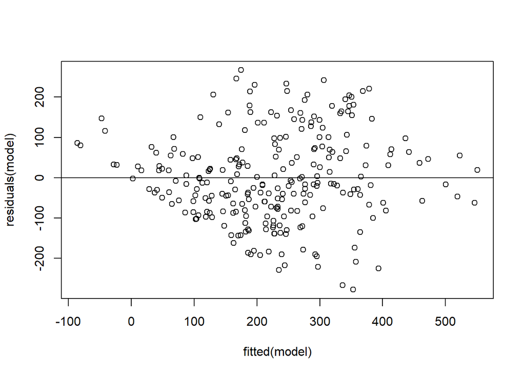

```
[1] "Normality of Resting"
```

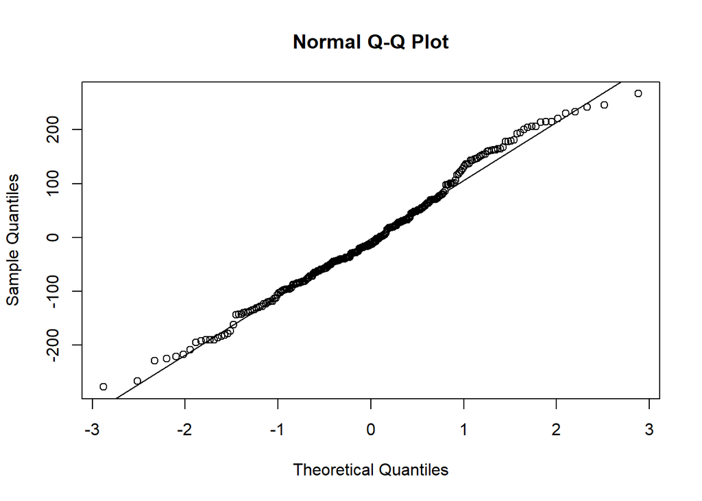

```
[1] "normality random residuals"
```

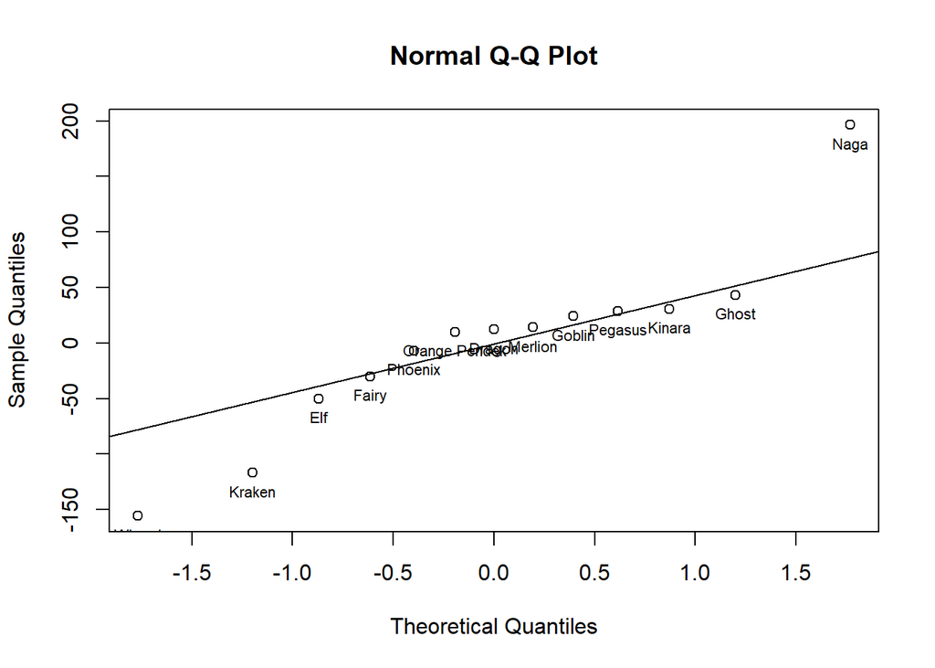

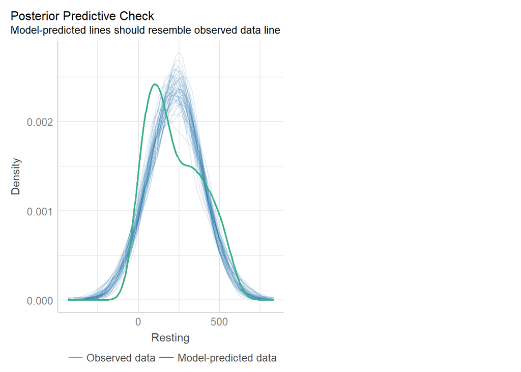

```r
lm_diagnosis(mResting)
```

**Up and down**

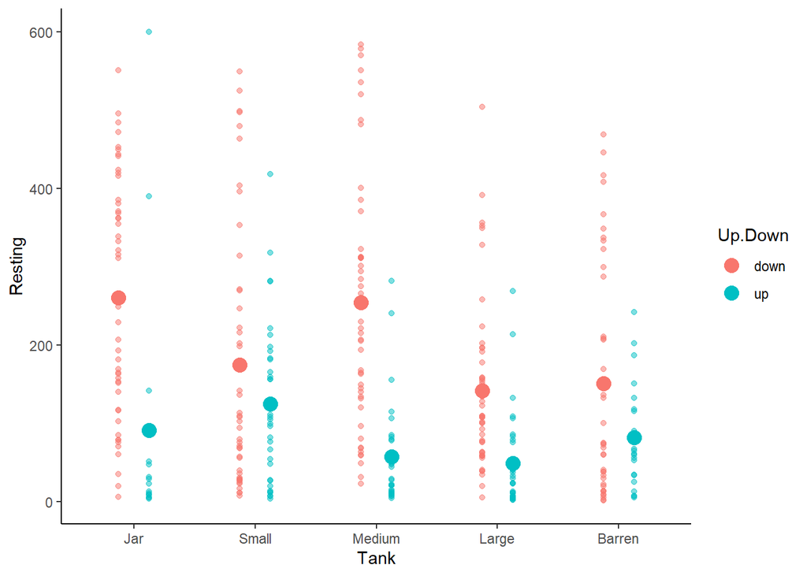

```r
dataUpDown %>% filter(Resting!=0) %>%
ggplot(.,aes(y = Resting, x = Tank, color = Up.Down)) +
  geom_jitter(alpha=.5, position = position_dodge(0.5))+
  stat_summary(fun = "mean", geom = "point", size = 4, position = position_dodge(0.5))
```

Irrespective of the tanks, the fish rested more time on the lower half of the tank than the upper half. This lower/upper difference in resting time was more or less pronounced depending on the tank.

**Resting place**

Just a plot with the amount of time resting at the different places depending on the tank. Each bar value is the mean of resting times over trials.

> Problem -> Resting on plants in Barren and Jar??

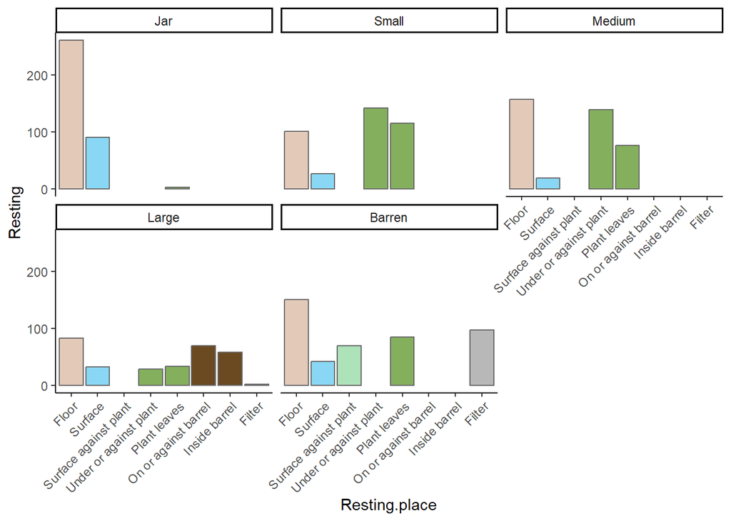

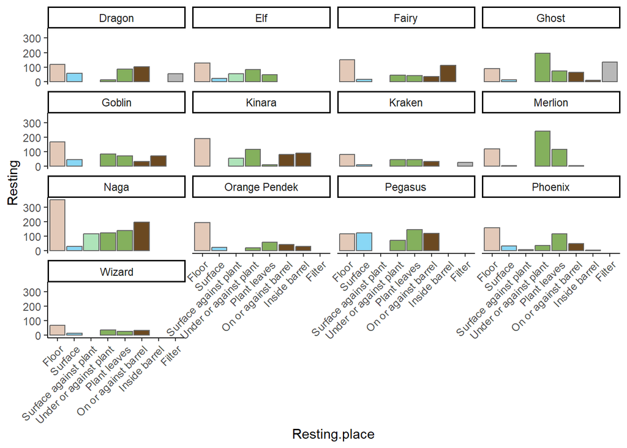

For the resting place, I don’t really know what to do and in fact what would be interesting to analyse. Fish are already shifting their resting places between tanks just because they have access to new resting places (filter, plants).